# MLDS 401/IEMS 404-1 (Fall 2023) - Lab 4 Solution

Yayu Zhou

2023-10-17

## [Hardwood Concentration]

```r
data = read.csv("~/Personal Drive/Northwestern University/Fall 2023/MLDS 401 - TA/Labs/hardwood.csv") %>%
  rename(Time = `Cooking.Time`) %>%
  mutate_at(vars(Hardwood, Time, Pressure), ~factor(.))
str(data)
```

```
## 'data.frame':    36 obs. of  4 variables:
##  $ Hardwood: Factor w/ 3 levels "2","4","8": 1 1 2 2 3 3 1 1 2 2 ...
##  $ Time    : Factor w/ 2 levels "3","4": 1 1 1 1 1 1 2 2 2 2 ...
##  $ Pressure: Factor w/ 3 levels "400","500","650": 1 1 1 1 1 1 1 1 1 1 ...
##  $ Strength: num  197 196 198 197 198 ...
```

### a) Fit model

```r
fit1 = aov(Strength ~ Hardwood * Time * Pressure, data = data)
summary(fit1)
```

```
##                        Df Sum Sq Mean Sq F value   Pr(>F)
## Hardwood                2  7.764   3.882  10.619   0.0009 ***
## Time                    1 20.250  20.250  55.395 6.75e-07 ***
## Pressure                2 19.374   9.687  26.499 4.33e-06 ***
## Hardwood:Time           2  2.082   1.041   2.847   0.0843 .
## Hardwood:Pressure       4  6.091   1.523   4.166   0.0146 *
## Time:Pressure           2  2.195   1.098   3.002   0.0750 .
## Hardwood:Time:Pressure  4  1.973   0.493   1.350   0.2903
## Residuals              18  6.580   0.366
## ---
## Signif. codes:  0 '***' 0.001 '**' 0.01 '*' 0.05 '.' 0.1 ' ' 1
```

```r
## alternative code
fit2 = lm(Strength ~ Hardwood * Time * Pressure, data = data)
anova(fit2)
```

```
## Analysis of Variance Table
##
## Response: Strength
##                        Df  Sum Sq Mean Sq F value    Pr(>F)
## Hardwood                2  7.7639  3.8819 10.6193 0.0008996 ***
## Time                    1 20.2500 20.2500 55.3951 6.745e-07 ***
## Pressure                2 19.3739  9.6869 26.4992 4.327e-06 ***
## Hardwood:Time           2  2.0817  1.0408  2.8473 0.0842597 .
## Hardwood:Pressure       4  6.0911  1.5228  4.1657 0.0146262 *
## Time:Pressure           2  2.1950  1.0975  3.0023 0.0749564 .
## Hardwood:Time:Pressure  4  1.9733  0.4933  1.3495 0.2903053
## Residuals              18  6.5800  0.3656
## ---
## Signif. codes:  0 '***' 0.001 '**' 0.01 '*' 0.05 '.' 0.1 ' ' 1
```

According to the ANOVA table, we can conclude:

1. The three factors hardwood concentration, cooking time and pressure all have relatively large $F$-statistic and $p$-values $< \alpha = 0.05$, so all the main effects are statistically significant.
2. Among all three two-way interaction terms, the interaction between hardwood concentration and cooking time (Hardwood$\times$Time) has $F$-statistic = 2.85 with $p$-value = 0.0843. The interaction between hardwood concentration and pressure (Hardwood$\times$Pressure) has $F$-statistic = 4.17 with $p$-value $= 0.0146 < \alpha = 0.05$. The interaction between cooking time and pressure (Time$\times$Pressure) has $F$-statistic = 3.00 with $p$-value = 0.0750. Therefore, the interaction between hardwood concentration and pressure is statistically significant, and the other two two-way interaction terms are not significant but they have relatively small p-values.
3. The three-way interaction term has $F$-statistic = 1.35 with $p$-value $= 0.2903 > \alpha = 0.05$, so it is not significant.

```r
## drop non-significant term
drop1(fit1) ## we should drop 3-way interaction
```

```
## Single term deletions
##
## Model:
## Strength ~ Hardwood * Time * Pressure
##                        Df Sum of Sq    RSS     AIC
## <none>                              6.5800 -25.181
## Hardwood:Time:Pressure  4    1.9733 8.5533 -23.739
```

### b) Model diagnostics

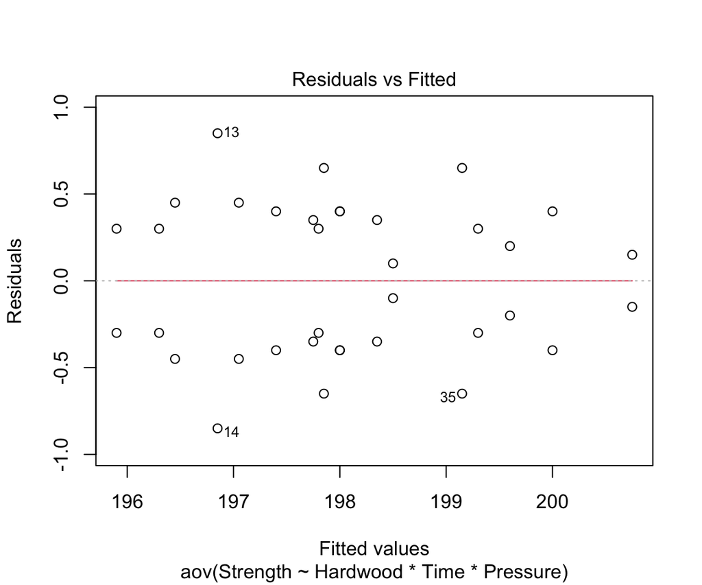

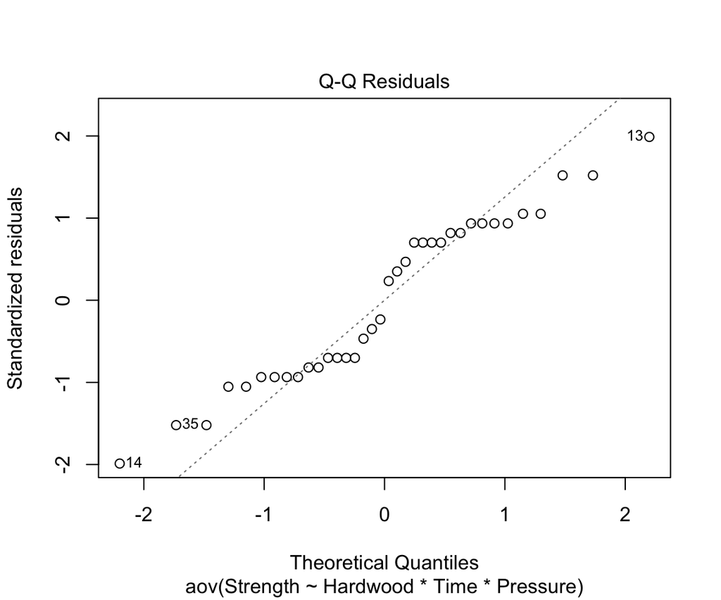

```r
plot(fit1, which = c(1, 2))
```

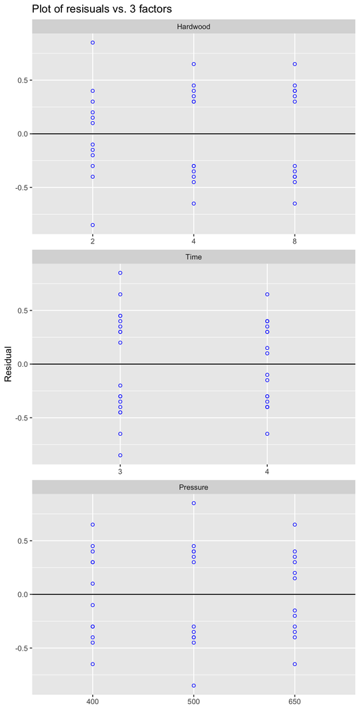

```r
# residual plot for each factor
data %>% select(-Strength) %>%
  mutate(res = fit1$residuals) %>%
  melt(., id.vars = c("res")) %>%
  ggplot(aes(x = value, y = res)) +
  geom_point(shape = 1, color = "blue") +
  geom_hline(aes(yintercept = 0)) +
  facet_wrap(~variable, nrow = 3, scale = "free_x") +
  labs(x = "", y = "Residual", title = "Plot of resisuals vs. 3 factors")
```

The above five plots of residuals are used to check basic assumptions:

1. In the QQ plot, the residuals slightly departure from the straight line in the middle region and shows a S-shape, which indicates that the normality assumption might be violated (but might not be a big problem since the departure is tiny).
2. According to the plot of residuals vs. predicted values, there is no obvious pattern: residuals are randomly distributed and form a roughly parallel band around the horizontal line about 0. According to the plot of residuals vs. hardwood concentration (1st in the panel), there is no obvious pattern: residuals are randomly distributed over types of hardwood and form a roughly parallel band around the horizontal line about 0. Similar results are obtained from the plot of residuals vs. cooking time (2nd in the panel) and vs. pressure (3rd in the panel). Therefore, the assumption of constant variance is satisfied. Besides, all plots show no obvious outliers.

Comment about model’s adequacy:

```r
sst = sum((data$Strength - mean(data$Strength))^2)
dft = nrow(data) - 1

sse = sum(fit1$residuals^2)
dfe = 18
mse = sse/dfe

ssr = sst - sse
dfr = dft - dfe
msr = ssr/dfr

fstats = msr/mse
pval = 1 - pf(q = fstats, df1 = dfr, df2 = dfe)
rsq = ssr/sst
```

We can compute $\text{SST}= \sum_{i = 1}^n(y_i - \bar{y})^2 = 66.3089$, $\text{SSE}= 6.58$, and $\text{SSR}= \text{SST}- \text{SSE}= 59.7289$. The ANOVA table for the overall model is summarized as follows:

| SS | DF | MS | F | p |
| --- | --- | --- | --- | --- |
| Model | 17 | 3.5135 | 9.6113 | 0 |
| Error | 18 | 0.3656 |  |  |
| Total | 35 |  |  |  |

1. For the model, we get $F$-statistic = 9.61 with $p$-value $< 0.0001 < \alpha = 0.05$, so we conclude that the model is significant and useful.
2. $R^2 = \frac{\text{SSR}}{SST} = 0.9008$. This indicates that about 90.08% of the variation in the response can be explained by the model, which is a good fit.

### c) Select the best treatment combination

The interaction plots are below:

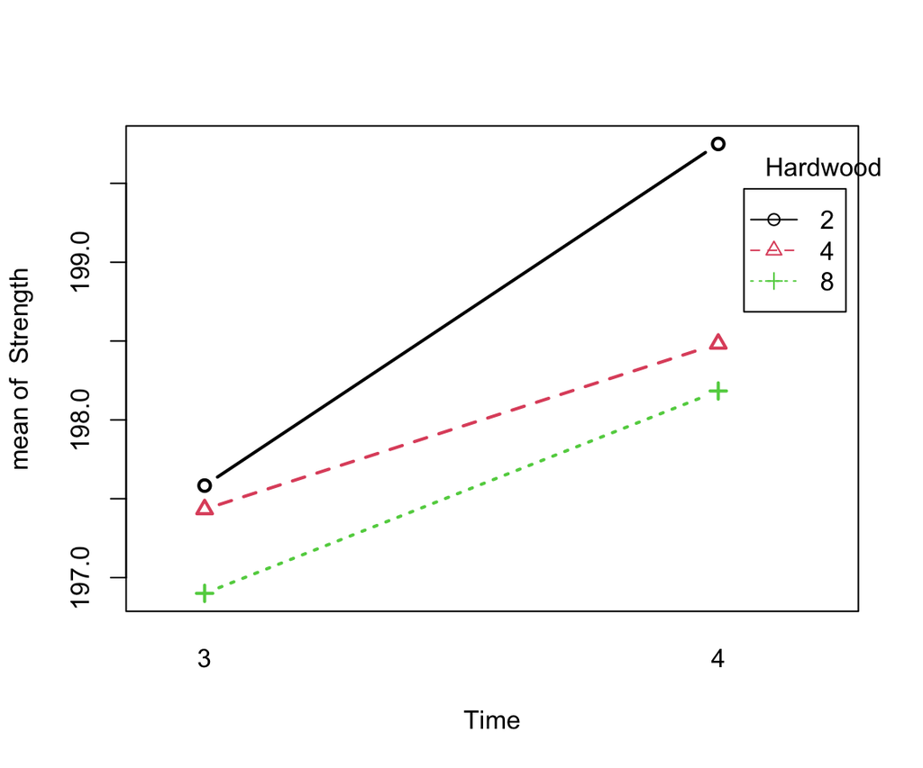

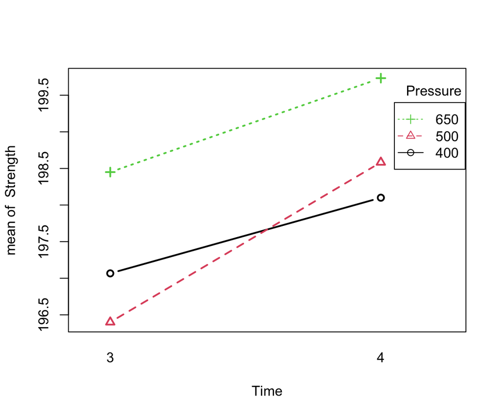

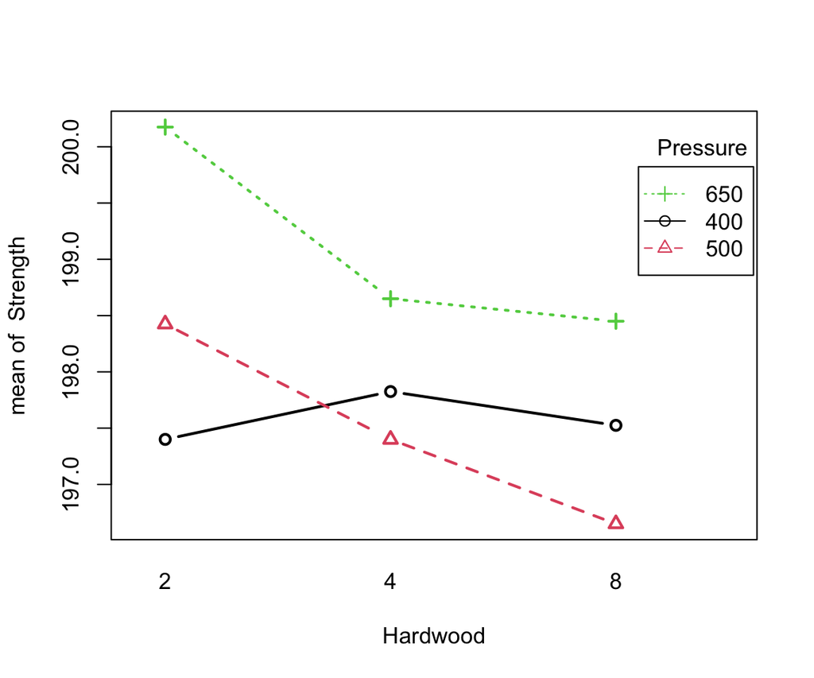

```r
## interaction plots
with(data, {
  interaction.plot(x.factor = Time, trace.factor = Hardwood, response = Strength,
                   type = "b", col = 1:3, lty = 1:3, lwd = 2, pch = 1:3, leg.bty = "o")
  interaction.plot(x.factor = Time, trace.factor = Pressure, response = Strength,
                   type = "b", col = 1:3, lty = 1:3, lwd = 2, pch = 1:3, leg.bty = "o")
  interaction.plot(x.factor = Hardwood, trace.factor = Pressure, response = Strength,
                   type = "b", col = 1:3, lty = 1:3, lwd = 2, pch = 1:3, leg.bty = "o")
})
```

To maximize the strength of paper, we should operate the process under the set of conditions: the percentage of hardwood concentration is 2, the cooking time of the pulp is 4.0 hours, and the vat pressure is 650.

We can also use Tukey’s method for pairwise comparisons for all treatment combinations. The treatment combination (hardwood = 2, time = 4 and pressure = 650) has the largest estimate.

```r
## Tukey's method
TukeyHSD(fit1, which = "Hardwood:Time:Pressure", ordered = T) ## only accepts AOV object
```

```
##   Tukey multiple comparisons of means
##     95% family-wise confidence level
##     factor levels have been ordered
##
## Fit: aov(formula = Strength ~ Hardwood * Time * Pressure, data = data)
##
## $`Hardwood:Time:Pressure`
##                         diff         lwr     upr     p adj
## 2:3:400-8:3:500 4.000000e-01 -2.03166969 2.83167 0.9999989
## 4:3:500-8:3:500 5.500000e-01 -1.88166969 2.98167 0.9999135
## 2:3:500-8:3:500 9.500000e-01 -1.48166969 3.38167 0.9691579
## 8:3:400-8:3:500 1.150000e+00 -1.28166969 3.58167 0.8780886
## 8:4:500-8:3:500 1.500000e+00 -0.93166969 3.93167 0.5669175
## 8:3:650-8:3:500 1.850000e+00 -0.58166969 4.28167 0.2666469
## 4:4:400-8:3:500 1.900000e+00 -0.53166969 4.33167 0.2347148
## 4:3:400-8:3:500 1.950000e+00 -0.48166969 4.38167 0.2057908
## 8:4:400-8:3:500 2.100000e+00 -0.33166969 4.53167 0.1358537
## 4:3:650-8:3:500 2.100000e+00 -0.33166969 4.53167 0.1358537
## 4:4:500-8:3:500 2.450000e+00  0.01833031 4.88167 0.0472028
## 2:4:400-8:3:500 2.600000e+00  0.16833031 5.03167 0.0292884
## 8:4:650-8:3:500 3.250000e+00  0.81833031 5.68167 0.0034951
## 4:4:650-8:3:500 3.400000e+00  0.96833031 5.83167 0.0021399
## 2:3:650-8:3:500 3.700000e+00  1.26833031 6.13167 0.0008110
## 2:4:500-8:3:500 4.100000e+00  1.66833031 6.53167 0.0002297
## 2:4:650-8:3:500 4.850000e+00  2.41833031 7.28167 0.0000244
## 4:3:500-2:3:400 1.500000e-01 -2.28166969 2.58167 1.0000000
## 2:3:500-2:3:400 5.500000e-01 -1.88166969 2.98167 0.9999135
## 8:3:400-2:3:400 7.500000e-01 -1.68166969 3.18167 0.9966489
## 8:4:500-2:3:400 1.100000e+00 -1.33166969 3.53167 0.9083121
## 8:3:650-2:3:400 1.450000e+00 -0.98166969 3.88167 0.6165444
## 4:4:400-2:3:400 1.500000e+00 -0.93166969 3.93167 0.5669175
## 4:3:400-2:3:400 1.550000e+00 -0.88166969 3.98167 0.5178504
## 8:4:400-2:3:400 1.700000e+00 -0.73166969 4.13167 0.3805461
## 4:3:650-2:3:400 1.700000e+00 -0.73166969 4.13167 0.3805461
## 4:4:500-2:3:400 2.050000e+00 -0.38166969 4.48167 0.1565192
## 2:4:400-2:3:400 2.200000e+00 -0.23166969 4.63167 0.1015118
## 8:4:650-2:3:400 2.850000e+00  0.41833031 5.28167 0.0130015
## 4:4:650-2:3:400 3.000000e+00  0.56833031 5.43167 0.0079468
## 2:3:650-2:3:400 3.300000e+00  0.86833031 5.73167 0.0029669
## 2:4:500-2:3:400 3.700000e+00  1.26833031 6.13167 0.0008110
```

[output cut: 106 more lines]

```
## 8:4:650-2:4:400 6.500000e-01 -1.78166969 3.08167 0.9993192
## 4:4:650-2:4:400 8.000000e-01 -1.63166969 3.23167 0.9935182
## 2:3:650-2:4:400 1.100000e+00 -1.33166969 3.53167 0.9083121
## 2:4:500-2:4:400 1.500000e+00 -0.93166969 3.93167 0.5669175
## 2:4:650-2:4:400 2.250000e+00 -0.18166969 4.68167 0.0874314
## 4:4:650-8:4:650 1.500000e-01 -2.28166969 2.58167 1.0000000
## 2:3:650-8:4:650 4.500000e-01 -1.98166969 2.88167 0.9999943
## 2:4:500-8:4:650 8.500000e-01 -1.58166969 3.28167 0.9883791
## 2:4:650-8:4:650 1.600000e+00 -0.83166969 4.03167 0.4700574
## 2:3:650-4:4:650 3.000000e-01 -2.13166969 2.73167 1.0000000
## 2:4:500-4:4:650 7.000000e-01 -1.73166969 3.13167 0.9984118
## 2:4:650-4:4:650 1.450000e+00 -0.98166969 3.88167 0.6165444
## 2:4:500-2:3:650 4.000000e-01 -2.03166969 2.83167 0.9999989
## 2:4:650-2:3:650 1.150000e+00 -1.28166969 3.58167 0.8780886
## 2:4:650-2:4:500 7.500000e-01 -1.68166969 3.18167 0.9966489
```

```r
## alternative method
library(emmeans)
output = lsmeans(fit1, pairwise ~ Hardwood * Time * Pressure)
output$lsmeans %>%
  data.frame(.) %>%
  arrange(desc(lsmean))
```

```
##    Hardwood Time Pressure lsmean        SE df lower.CL upper.CL
## 1         2    4      650 200.75 0.4275252 18 199.8518 201.6482
## 2         2    4      500 200.00 0.4275252 18 199.1018 200.8982
## 3         2    3      650 199.60 0.4275252 18 198.7018 200.4982
## 4         4    4      650 199.30 0.4275252 18 198.4018 200.1982
## 5         8    4      650 199.15 0.4275252 18 198.2518 200.0482
## 6         2    4      400 198.50 0.4275252 18 197.6018 199.3982
## 7         4    4      500 198.35 0.4275252 18 197.4518 199.2482
## 8         8    4      400 198.00 0.4275252 18 197.1018 198.8982
## 9         4    3      650 198.00 0.4275252 18 197.1018 198.8982
## 10        4    3      400 197.85 0.4275252 18 196.9518 198.7482
## 11        4    4      400 197.80 0.4275252 18 196.9018 198.6982
## 12        8    3      650 197.75 0.4275252 18 196.8518 198.6482
## 13        8    4      500 197.40 0.4275252 18 196.5018 198.2982
## 14        8    3      400 197.05 0.4275252 18 196.1518 197.9482
## 15        2    3      500 196.85 0.4275252 18 195.9518 197.7482
## 16        4    3      500 196.45 0.4275252 18 195.5518 197.3482
## 17        2    3      400 196.30 0.4275252 18 195.4018 197.1982
## 18        8    3      500 195.90 0.4275252 18 195.0018 196.7982
```

```r
## maximal strength is obtained at hardwood = 2, time = 4, and pressure = 650

## same pairwise comparison as Tukey's comparison
output$contrasts
```

```
##  contrast                                                  estimate    SE df
##  Hardwood2 Time3 Pressure400 - Hardwood4 Time3 Pressure400    -1.55 0.605 18
##  Hardwood2 Time3 Pressure400 - Hardwood8 Time3 Pressure400    -0.75 0.605 18
##  Hardwood2 Time3 Pressure400 - Hardwood2 Time4 Pressure400    -2.20 0.605 18
##  Hardwood2 Time3 Pressure400 - Hardwood4 Time4 Pressure400    -1.50 0.605 18
##  Hardwood2 Time3 Pressure400 - Hardwood8 Time4 Pressure400    -1.70 0.605 18
##  Hardwood2 Time3 Pressure400 - Hardwood2 Time3 Pressure500    -0.55 0.605 18
##  Hardwood2 Time3 Pressure400 - Hardwood4 Time3 Pressure500    -0.15 0.605 18
##  Hardwood2 Time3 Pressure400 - Hardwood8 Time3 Pressure500     0.40 0.605 18
##  Hardwood2 Time3 Pressure400 - Hardwood2 Time4 Pressure500    -3.70 0.605 18
##  Hardwood2 Time3 Pressure400 - Hardwood4 Time4 Pressure500    -2.05 0.605 18
##  Hardwood2 Time3 Pressure400 - Hardwood8 Time4 Pressure500    -1.10 0.605 18
##  Hardwood2 Time3 Pressure400 - Hardwood2 Time3 Pressure650    -3.30 0.605 18
##  Hardwood2 Time3 Pressure400 - Hardwood4 Time3 Pressure650    -1.70 0.605 18
##  Hardwood2 Time3 Pressure400 - Hardwood8 Time3 Pressure650    -1.45 0.605 18
##  Hardwood2 Time3 Pressure400 - Hardwood2 Time4 Pressure650    -4.45 0.605 18
##  Hardwood2 Time3 Pressure400 - Hardwood4 Time4 Pressure650    -3.00 0.605 18
##  Hardwood2 Time3 Pressure400 - Hardwood8 Time4 Pressure650    -2.85 0.605 18
##  Hardwood4 Time3 Pressure400 - Hardwood8 Time3 Pressure400     0.80 0.605 18
##  Hardwood4 Time3 Pressure400 - Hardwood2 Time4 Pressure400    -0.65 0.605 18
##  Hardwood4 Time3 Pressure400 - Hardwood4 Time4 Pressure400     0.05 0.605 18
##  Hardwood4 Time3 Pressure400 - Hardwood8 Time4 Pressure400    -0.15 0.605 18
##  Hardwood4 Time3 Pressure400 - Hardwood2 Time3 Pressure500     1.00 0.605 18
##  Hardwood4 Time3 Pressure400 - Hardwood4 Time3 Pressure500     1.40 0.605 18
##  Hardwood4 Time3 Pressure400 - Hardwood8 Time3 Pressure500     1.95 0.605 18
##  Hardwood4 Time3 Pressure400 - Hardwood2 Time4 Pressure500    -2.15 0.605 18
##  Hardwood4 Time3 Pressure400 - Hardwood4 Time4 Pressure500    -0.50 0.605 18
##  Hardwood4 Time3 Pressure400 - Hardwood8 Time4 Pressure500     0.45 0.605 18
##  Hardwood4 Time3 Pressure400 - Hardwood2 Time3 Pressure650    -1.75 0.605 18
##  Hardwood4 Time3 Pressure400 - Hardwood4 Time3 Pressure650    -0.15 0.605 18
##  Hardwood4 Time3 Pressure400 - Hardwood8 Time3 Pressure650     0.10 0.605 18
##  Hardwood4 Time3 Pressure400 - Hardwood2 Time4 Pressure650    -2.90 0.605 18
##  Hardwood4 Time3 Pressure400 - Hardwood4 Time4 Pressure650    -1.45 0.605 18
##  Hardwood4 Time3 Pressure400 - Hardwood8 Time4 Pressure650    -1.30 0.605 18
##  Hardwood8 Time3 Pressure400 - Hardwood2 Time4 Pressure400    -1.45 0.605 18
##  Hardwood8 Time3 Pressure400 - Hardwood4 Time4 Pressure400    -0.75 0.605 18
##  Hardwood8 Time3 Pressure400 - Hardwood8 Time4 Pressure400    -0.95 0.605 18
##  Hardwood8 Time3 Pressure400 - Hardwood2 Time3 Pressure500     0.20 0.605 18
##  Hardwood8 Time3 Pressure400 - Hardwood4 Time3 Pressure500     0.60 0.605 18
##  Hardwood8 Time3 Pressure400 - Hardwood8 Time3 Pressure500     1.15 0.605 18
```

[output cut: 255 more lines]

```
##   -1.902  0.8781
##    0.496  1.0000
##    0.744  1.0000
##    0.413  1.0000
##   -4.548  0.0180
##   -2.150  0.7603
##   -1.902  0.8781
##   -4.962  0.0079
##   -2.564  0.5179
##   -2.316  0.6659
##    2.398  0.6165
##    2.646  0.4701
##    0.248  1.0000
##
## P value adjustment: tukey method for comparing a family of 18 estimates
```

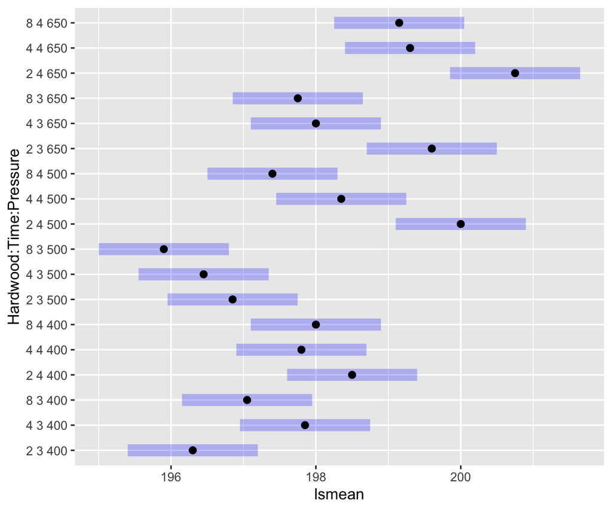

```r
## visualization
plot(output)
```